# Simple Linear Regression III

## Some chatter from the internets

## 2016 Election

[figure not shown]

**Question at hand**: How will Obama's 46% approval rating effect his party's candidate for the 2016 presidential election?

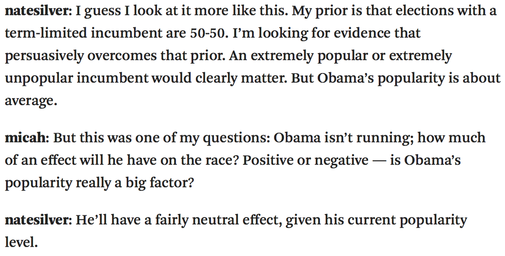

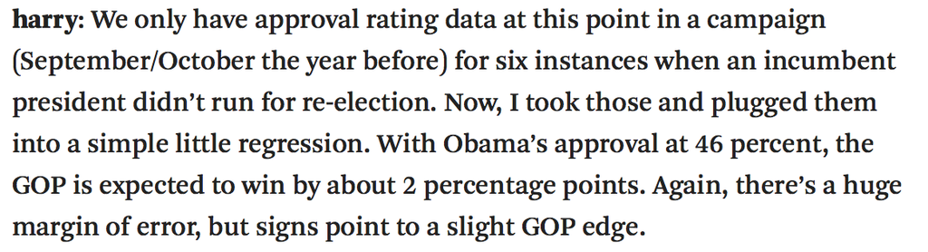

### How would you visualize this data?

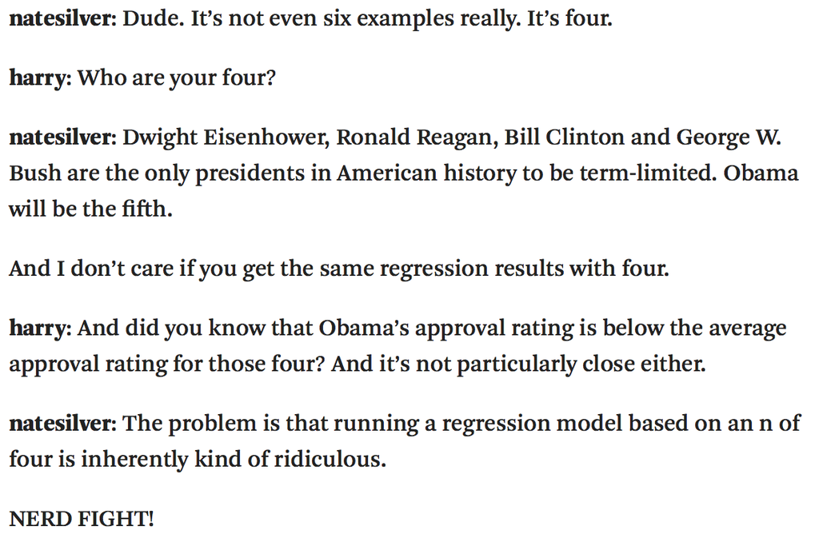

### Why is it ridiculous?

## Inference for Regression

We can fit a line through any cloud of points that we please, but if we just have a *sample* of data, any trend we detect doesn't necessarily demonstrate that the trend exists in the *population* at large.

## Plato's Allegory of the Cave

[figure not shown]

## Statistical Inference

**Goal**: use *statistics* calculated from data to makes inferences about the nature of *parameters*.

In regression,

- parameters: \(\beta_0\), \(\beta_1\)
- statistics: \(b_0\), \(b_1\)

Classical tools of inference:

- Confidence Intervals
- Hypothesis Tests

## Unemployment and elections

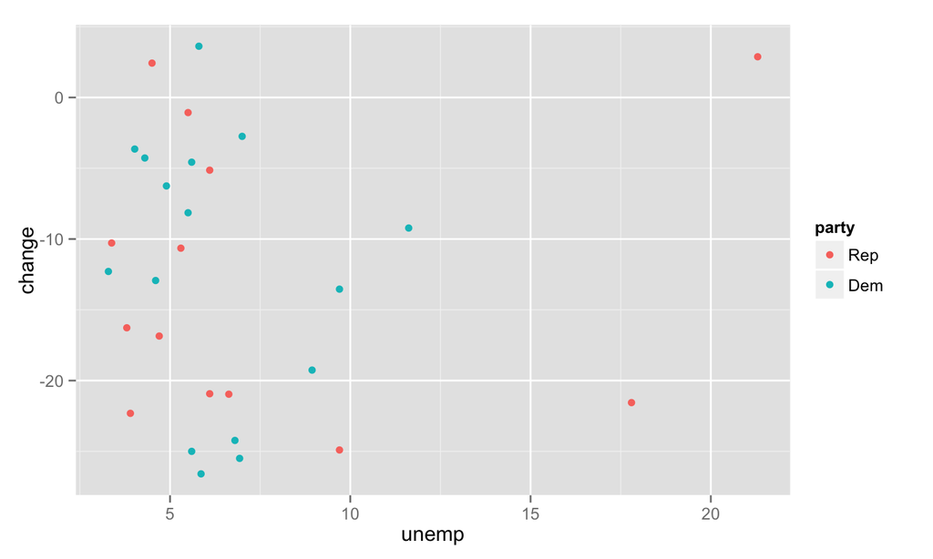

**Reigning theory**: voters will punish candidates from the Presidents party at the ballot box when unemployment is high.

## Unemployment and elections

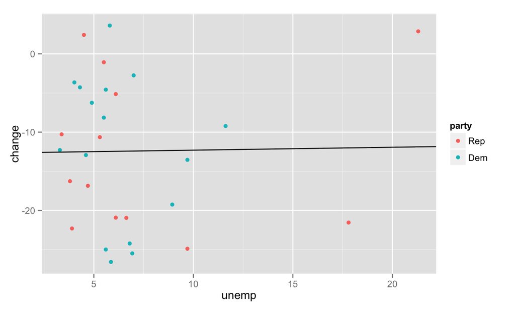

**Reigning theory**: voters will punish candidates from the Presidents party at the ballot box when unemployment is high.

## Unemployment and elections

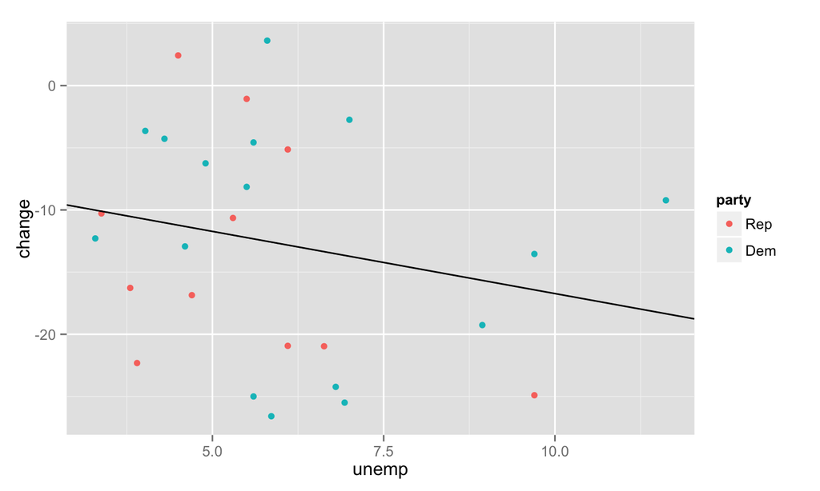

Some evidence of a negative linear relationship between unemployment level and change in party support - or is there?

## H-test for Regression

\(H_0:\) There is no relationship between unemployment level and change in party support.

\(H_O: \beta_1 = 0\)

### Method

If there is no relationship, the pairing between \(X\) and \(Y\) is artificial and we can randomize:

1. Create synthetic data sets under \(H_0\) by shuffling \(X\).
2. Compute a new regression line for each data set and store each \(b_1\).
3. See where your observed \(b_1\) falls in the distribution of \(b_1\)'s under \(H_0\).

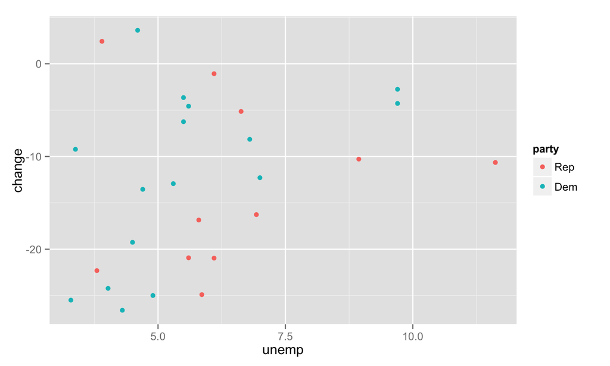

```r
ump_shuffled$unemp <- sample(ump_shuffled$unemp)
qplot(x = unemp, y = change, col = party, data = ump_shuffled)
```

## First \(b_1\)

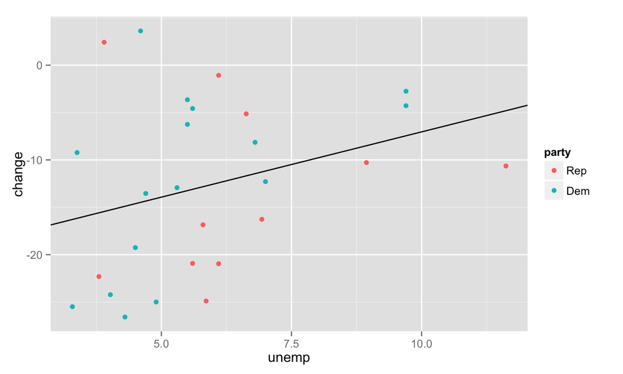

## Second \(b_1\)

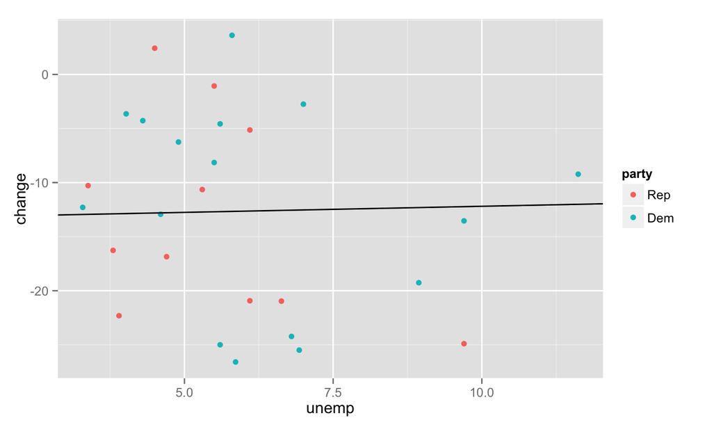

## 100 \(b_1\)'s

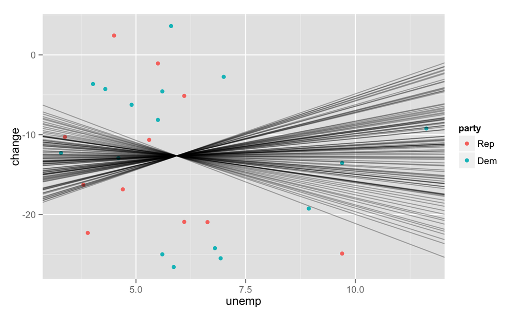

## Sampling dist. of \(b_1\)

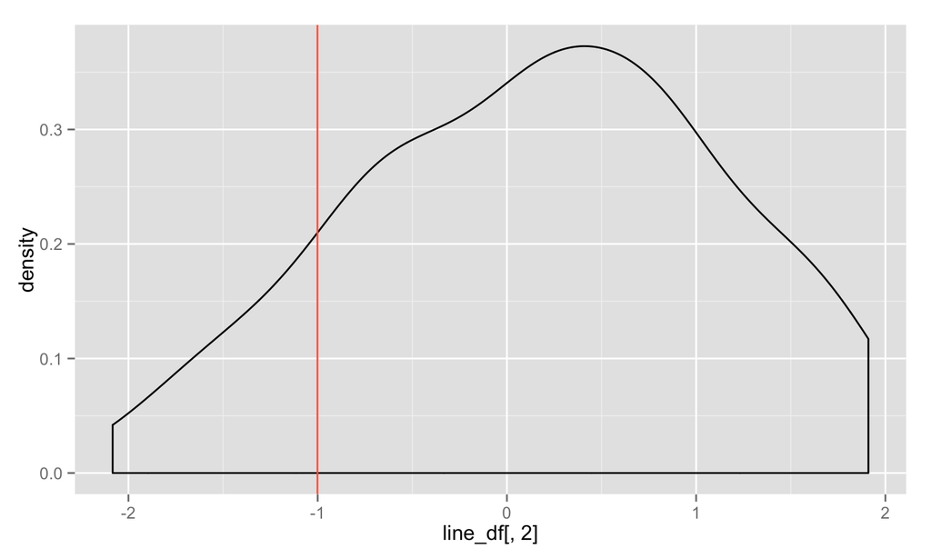

## H-tests for regression

```r
m0 <- lm(change ~ unemp, data = ump)
summary(m0)
```

```
##
## Call:
## lm(formula = change ~ unemp, data = ump)
##
## Residuals:
##     Min      1Q  Median      3Q     Max
## -14.011  -7.861  -0.183   7.389  16.140
##
## Coefficients:
##             Estimate Std. Error t value Pr(>|t|)
## (Intercept)   -6.714      5.457   -1.23     0.23
## unemp         -1.001      0.872   -1.15     0.26
##
## Residual standard error: 9.11 on 25 degrees of freedom
## Multiple R-squared:  0.0501, Adjusted R-squared:  0.0121
## F-statistic: 1.32 on 1 and 25 DF,  p-value: 0.262
```

## H-tests for regression

- Each line in the summary table is a hypothesis test that the parameter is zero.
- Under certain conditions, the test statistic associated with \(b\)'s is distributed like \(t\) random variables with \(n - p\) degrees of freedom.

\[ \frac{b - \beta}{SE} \sim t_{df = n - p}\]

```r
t_stat <- (-1.0010 - 0)/0.8717
pt(t_stat, df = 27 - 2) * 2
```

```
## [1] 0.262
```

## Conditions for inference

1. **Linearity**: linear trend between \(X\) and \(Y\), check with residual plot.
2. **Independent errors**: check with residual plot for serial correlation.
3. **Normally distributed errors**: check for linearity in qq-plot.
4. **Errors with constant variance**: look for constant spread in residual plot.

[figure not shown]